# Categóricos

Variables categoricas o variables de texto

```python
import seaborn as sns
import matplotlib.pyplot as plt
```

```python
tips = sns.load_dataset('tips')
tips.head(3)
```

|  | total_bill | tip | sex | smoker | day | time | size |
| --- | --- | --- | --- | --- | --- | --- | --- |
| 0 | 16.99 | 1.01 | Female | No | Sun | Dinner | 2 |
| 1 | 10.34 | 1.66 | Male | No | Sun | Dinner | 3 |
| 2 | 21.01 | 3.50 | Male | No | Sun | Dinner | 3 |

## Countplot

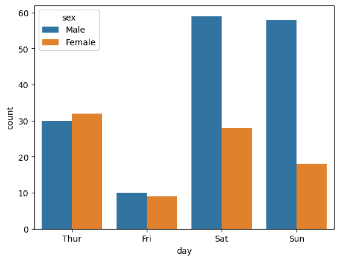

```python
#Haciendo gráficas
sns.countplot(data=tips,x='day',hue='sex')
plt.show()
```

### Explicación:

Haciendo una gráfica de nuestro dataframe `tips` de la variable `x = day` y haciendo una segmentación `(hue)` por variable `sex` que representa el Género.

### También lo podemos gráficar en el eje Y

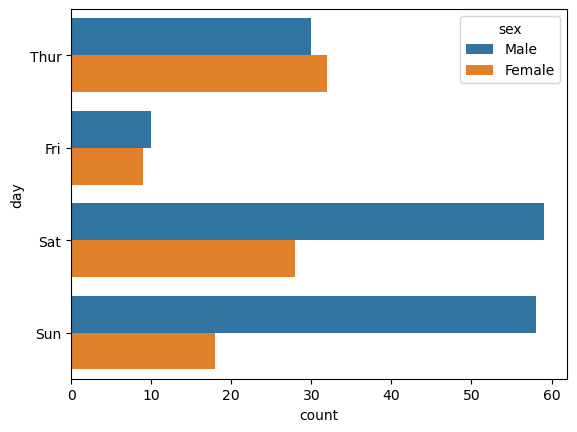

```python
#Countplot
sns.countplot(data=tips,y='day',hue='sex')
plt.show()
```

Como se puede observar el gráfico se acomoda automaticamente.

## Strip plot

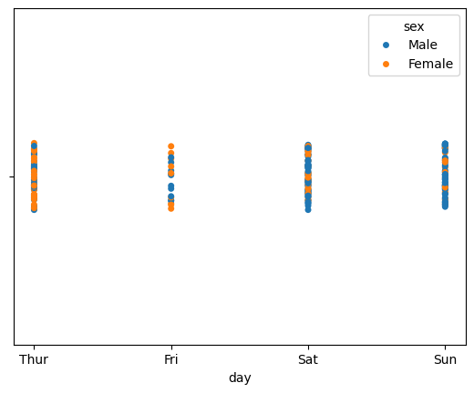

```python
#stripplot
sns.stripplot(data=tips,x='day',hue='sex')
plt.show()
```

Este gráfico se ve algo complicado, pero le daremos contexto.

### Explicación

Como ya no estoy contando las variables, debo especificarle que quiero ver de esas variables categóricas:

- Le especificamos que en `y ='total_bill'`, es decir le decimos que en `y` quiero el total de la cuenta.
- En x puedo ver el comportamiento a traves de la variable categorica por `day`.
- Le especificamos `dodge = True`, para poder ver el comportamiento de la segmentación que hicimos. En este caso ver el comportamiento de `total_bill` entre `hombres` y `mujeres`.

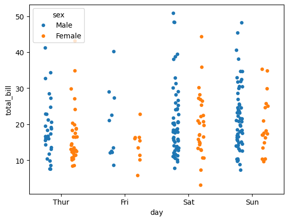

### Análisis:

Se puede observar que en el día `Sábado` hay pocos registros por parte de los `hombres` que `pagan una cuenta excesiva`,también se puede ver que hay `pocos puntos o registros` en el día `Viernes`

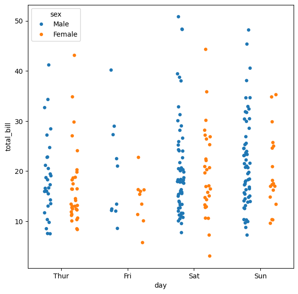

```python
#stripplot
#Ampliando la gráfica para ver mejor los resultados
plt.figure(figsize=(7,7))
sns.stripplot(data=tips,x='day',y='total_bill',hue='sex',dodge=True)
plt.show()
```

## Swarmplot

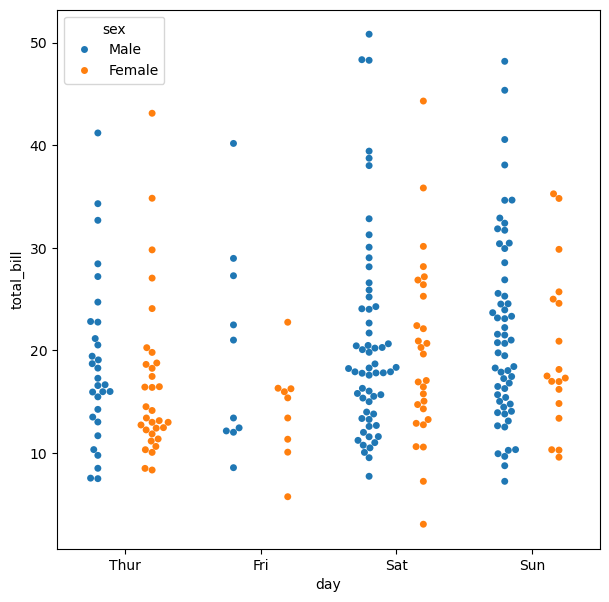

```python
#swarmplot
#Ampliando la gráfica para ver mejor los resultados
plt.figure(figsize=(7,7))
sns.swarmplot(data=tips,x='day',y='total_bill',hue='sex',dodge=True)
plt.show()
```

### Explicación:

Este tipo de gráfico es similar al anterior, pero con una excepción.

> En la **concentración de datos** voy a tener un *eje Horizontal*

[figure not shown]

## Boxplot

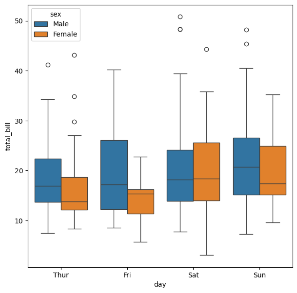

```python
#Boxplot
#Ampliando la gráfica para ver mejor los resultados
plt.figure(figsize=(7,7))
sns.boxplot(data=tips,x='day',y='total_bill',hue='sex',dodge=True)
plt.show()
```

### Explicación

Este tipo de gráfico nos ayuda a ver percentiles y otros parametros ademas, podemos ver la media de hombres casi en todos los días es más alta que de mujeres.  
También me sirve para gráficar variables:

- Númericas
- Categoricas

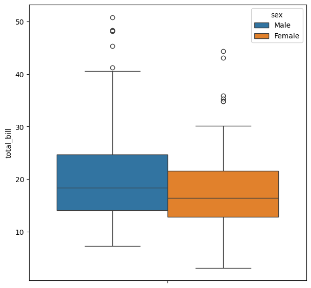

```python
#Boxplot con total bill
#Ampliando la gráfica para ver mejor los resultados
plt.figure(figsize=(7,7))
sns.boxplot(data=tips,y='total_bill',hue='sex')
plt.show()
```

### Puedo combinar Swarm plot y boxplot

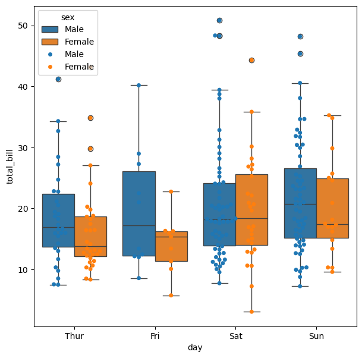

```python
#Boxplot + Swarmplot
#Ampliando la gráfica para ver mejor los resultados
plt.figure(figsize=(7,7))
sns.boxplot(data=tips,x='day',y='total_bill',hue='sex',dodge=True)
sns.swarmplot(data=tips,x='day',y='total_bill',hue='sex',dodge=True)
plt.show()
```

## Cambios:

Le cambiare el color al Swarmplot `color=0`

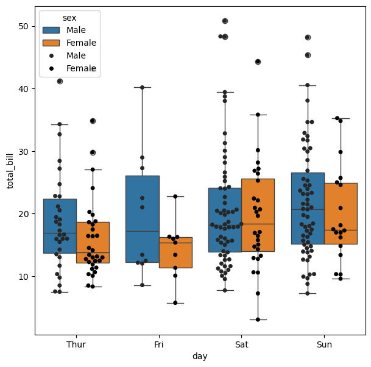

```python
#Boxplot + Swarmplot
#Ampliando la gráfica para ver mejor los resultados
plt.figure(figsize=(7,7))
sns.boxplot(data=tips,x='day',y='total_bill',hue='sex',dodge=True)
sns.swarmplot(data=tips,x='day',y='total_bill',hue='sex',dodge=True,color='0')
plt.show()
```

### Hay cambios en la versión de Seaborn

```
palette='dark:0'
```

Además `marker='*'`

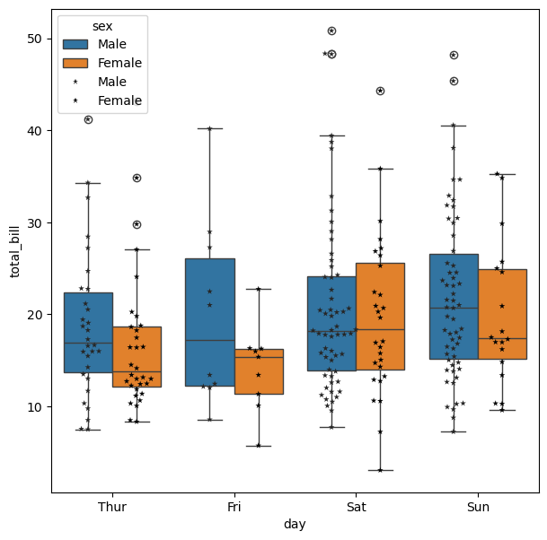

```python
#Boxplot + Swarmplot
#Ampliando la gráfica para ver mejor los resultados
plt.figure(figsize=(7,7))
sns.boxplot(data=tips,x='day',y='total_bill',hue='sex',dodge=True)
sns.swarmplot(data=tips,x='day',y='total_bill',hue='sex',dodge=True,palette='dark:0',marker='*')
plt.show()
```

Puedo personalizar como se trabaja la gráfica

## Violin plot

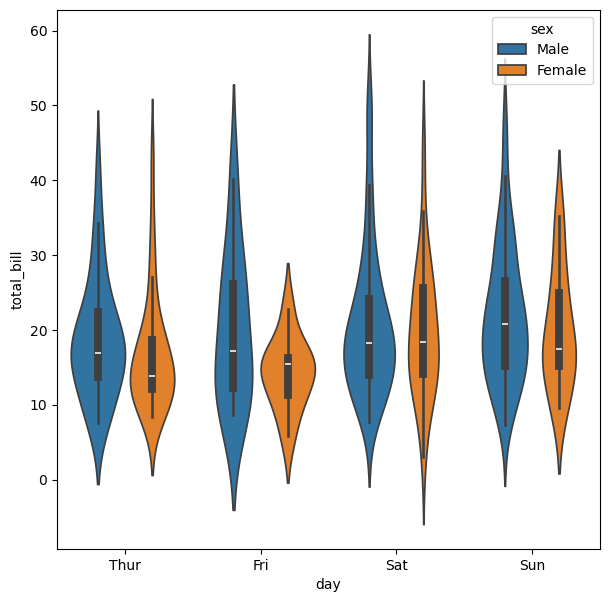

```python
#Violin plot
plt.figure(figsize=(7,7))
sns.violinplot(data=tips,x='day',y='total_bill',hue='sex',dodge=True)
plt.show()
```

### Explicación:

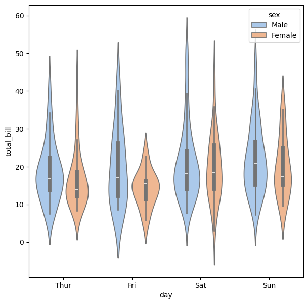

```python
#Violin plot
plt.figure(figsize=(7,7))
#Cambiando la paleta de colores
sns.violinplot(data=tips,x='day',y='total_bill',hue='sex',dodge=True,palette='pastel')
plt.show()
```

### Combinando los graficos

Recordemos:

- `dodge=True`: Me permite ver 2 gráficos separados por la `Segmentación` que hicimos.

Resaltemos:

- `split=True`: Me permite combinar los 2 gráficos que me entrega la `Segmentación` de `dodge`, en un solo gráfico. Es decir los junta o divide la visualización *'mitad y mitad'*.

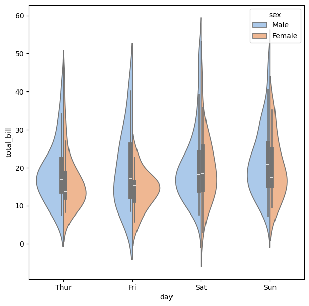

```python
#Violin plot
plt.figure(figsize=(7,7))
#Aplicando split
sns.violinplot(data=tips,x='day',y='total_bill',hue='sex',dodge=True,palette='pastel',split=True)
plt.show()
```

### También se puede usar en variables númericas

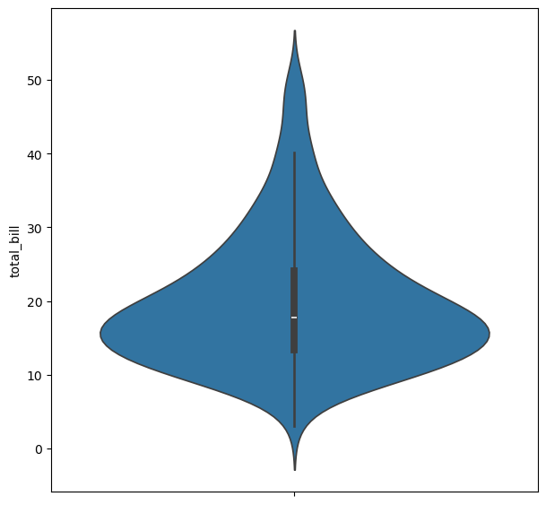

```python
#Violin plot para variables númericas
plt.figure(figsize=(7,7))
#Aplicando split
sns.violinplot(data=tips,y='total_bill')
plt.show()
```

## Cat plot

Va a graficar variables categoricas

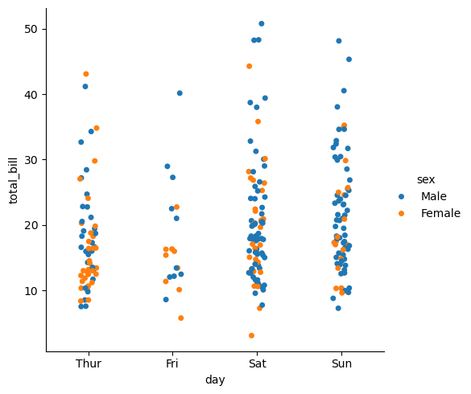

```python
#Catplot
sns.catplot(data=tips,x='day',y='total_bill',hue='sex')
plt.show()
```

En este caso sin definir el tipo de gráfico, este método decide que trabajará con `stripplot`. Simplemente lo deja así, pero apliquemosle un `dodge=True`

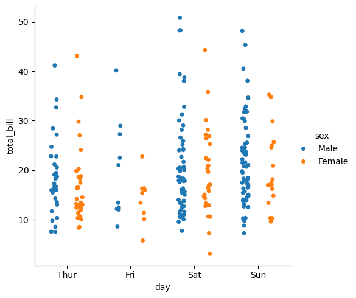

```python
#Cat plot
sns.catplot(data=tips,x='day',y='total_bill',hue='sex',dodge=True)
plt.show()
```

#### Parametro `kind=`

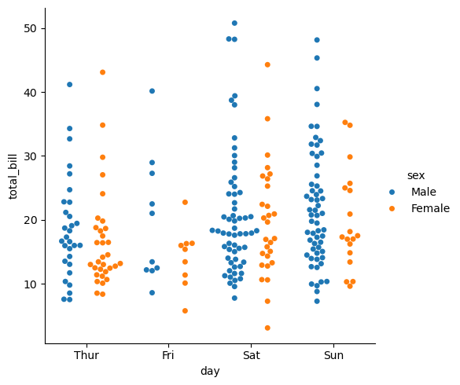

```python
#Cat plot
#kind='swarm'
sns.catplot(data=tips,x='day',y='total_bill',hue='sex',dodge=True,kind='swarm')
plt.show()
```

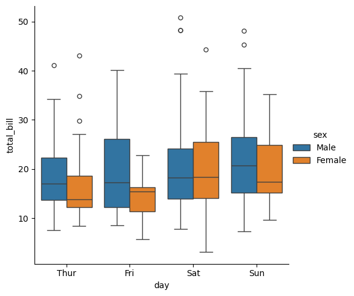

```python
#Cat plot
#kind='box'
sns.catplot(data=tips,x='day',y='total_bill',hue='sex',dodge=True,kind='box')
plt.show()
```

Puedo usar cualquier gráfica que use anteriormente, solo cambiando el parámetro de `kind`. Ademas puedo usar un parámetro extra `col`

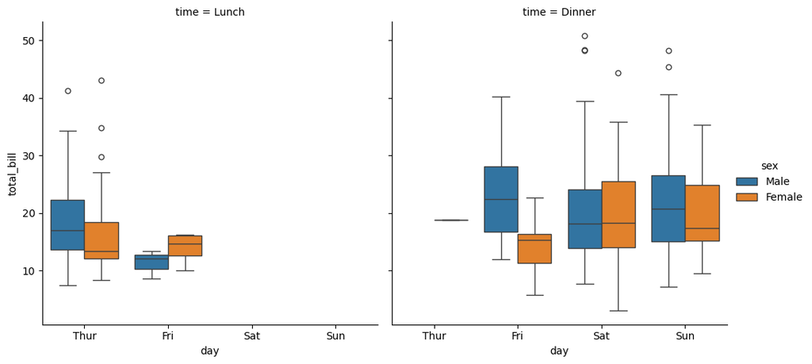

```python
#Cat plot
#kind='box'
#col='time'
sns.catplot(data=tips,x='day',y='total_bill',hue='sex',dodge=True,kind='box',col='time')
plt.show()
```

Ahora tengo 2 gráficas `Almuerzo` y `Cena`, para saber como se comportaron entre los distintos dias `day` en cuanto a cuenta total `total_bill`.

Así puedo trabajar con 3 distintas variables solo con agregar un parametro como `col`

# Referencia:

- [Visualizing categorical data](https://seaborn.pydata.org/tutorial/categorical.html)